# MPN bulk WGS n30 - SNV signature analysis

# Aim

This analysis is to explore the SNV mutational signatures in the bulk WGS MPN cohort (n30)

# 0. Setup

## a. Set ref genome

```r
SPECIES = "Hsapiens"
SPECIES_BUILD="hg19"
```

## b. Load libraries

```r
knitr::opts_chunk$set(collapse = TRUE)

library("BSgenome.Hsapiens.UCSC.hg19")

library("tidyverse")
library("ggrepel")
library("parallel")
library("magrittr")
library("patchwork")

source("revised_sigs.R")
source("contribution.plot.R")

theme_set(theme_bw())
```

## c. Custom functions

```r
  addTotal <-
    function(df) {
      df %>%
        mutate(across(where(is.logical), as.character)) %>%
        bind_rows(summarise(., across(where(is.numeric), ~ sum(.x, na.rm = T)),
                            across(where(is.character), ~ "Total")))
    }
```

## d. Create signature catalogue

Use COSMIC_v3.2_SBS_GRCh37.txt and add SBSblood from Machado et al. 2022 https://doi.org/10.1038/s41586-022-05072-7

```r
pcawg <- get_pcawg60()
pcawg.row.names <- row.names(pcawg)
# SBSblood signature from Table S8 Machado et al. 2022
lym <- read.table("lympho_sbs_sigs.txt", head = T, stringsAsFactors = FALSE)
pcawg <- cbind(pcawg, SBSblood = lym[, "SBSblood"])

pcawg <- apply(pcawg, MARGIN = 2, as.numeric)
row.names(pcawg) <- pcawg.row.names
```

## e. Data

### i. Clone_driver.key.n104

Clone-level metadata for 104 clones inferred by dpclust for the 30 MPN patients in the bulk WGS cohort.

```r
clone_driver.key.n104 <- read_csv("20260410_clone_driver.key.n104.csv")
```

#### 1) Summary

```r
clone_driver.key.n104 %>%
  group_by(Patient, category_label) %>%
  summarise(clone_tot = length(cluster_no), HQ.clone_tot = sum(In.vignette == TRUE, na.rm = T), .groups = "drop") %>%
  arrange(desc(category_label)) %>% addTotal()
```

| Patient | category_label | clone_tot | HQ.clone_tot |
| --- | --- | --- | --- |
| PD11408 | Transformed MF | 3 | 2 |
| PD11471 | Transformed MF | 3 | 2 |
| PD4060 | Transformed MF | 3 | 3 |
| PD4775 | Transformed MF | 4 | 3 |
| PD4947 | Transformed MF | 5 | 4 |
| PD5179 | Transformed MF | 3 | 2 |
| PD6635 | Transformed MF | 3 | 3 |
| PD8943 | Transformed MF | 4 | 2 |
| PD11410 | Transformed AML | 3 | 2 |
| PD14393 | Transformed AML | 4 | 3 |

[output cut: 21 more lines]

#### 2) Add Patient x cluster name

```r
clone_driver.key.n104 %<>%  mutate(cluster_name = paste0(Patient, "_", cluster_no))
```

#### 3) Check for multiple clones within the same patient

PD4775 & PD4947 have multiple 9pLOH containing clones

```r
clone_driver.key.n104 %>% filter(!is.na(Clone_abv)) %>% group_by(Patient) %>%  count(Clone_abv) %>%  filter(n>1)
```

| Patient | Clone_abv | n |
| --- | --- | --- |
| PD4775 | 9pLOH | 2 |
| PD4947 | 9pLOH | 2 |

```r
clone_driver.key.n104 %>% filter(Patient  %in% c("PD4775", "PD4947"))
```

| Patient | category_label | cluster_no | In.vignette | Clone_abv | cluster_name |
| --- | --- | --- | --- | --- | --- |
| PD4775 | Transformed MF | cl1 | TRUE | JAK2/TET2 | PD4775_cl1 |
| PD4775 | Transformed MF | cl3 | TRUE | 9pLOH | PD4775_cl3 |
| PD4775 | Transformed MF | cl4 | TRUE | 9pLOH | PD4775_cl4 |
| PD4775 | Transformed MF | cl5 | NA | NA | PD4775_cl5 |
| PD4947 | Transformed MF | cl1 | TRUE | JAK2 | PD4947_cl1 |
| PD4947 | Transformed MF | cl3 | TRUE | ASXL1/9pLOH | PD4947_cl3 |
| PD4947 | Transformed MF | cl5 | TRUE | 9pLOH | PD4947_cl5 |
| PD4947 | Transformed MF | cl6 | TRUE | 9pLOH | PD4947_cl6 |
| PD4947 | Transformed MF | cl7 | NA | NA | PD4947_cl7 |

##### i) Add cluster_no suffix to 9pLOH only clones

```r
clone_driver.key.n104 %>%
  mutate(Clone_abv = case_when(cluster_name %in% c("PD4775_cl3", "PD4775_cl4", "PD4947_cl5", "PD4947_cl6") & Clone_abv == "9pLOH" ~ paste0(Clone_abv, ".", cluster_no), TRUE ~ Clone_abv)) %>%
  filter(Patient  %in% c("PD4775", "PD4947"))
```

| Patient | category_label | cluster_no | In.vignette | Clone_abv | cluster_name |
| --- | --- | --- | --- | --- | --- |
| PD4775 | Transformed MF | cl1 | TRUE | JAK2/TET2 | PD4775_cl1 |
| PD4775 | Transformed MF | cl3 | TRUE | 9pLOH.cl3 | PD4775_cl3 |
| PD4775 | Transformed MF | cl4 | TRUE | 9pLOH.cl4 | PD4775_cl4 |
| PD4775 | Transformed MF | cl5 | NA | NA | PD4775_cl5 |
| PD4947 | Transformed MF | cl1 | TRUE | JAK2 | PD4947_cl1 |
| PD4947 | Transformed MF | cl3 | TRUE | ASXL1/9pLOH | PD4947_cl3 |
| PD4947 | Transformed MF | cl5 | TRUE | 9pLOH.cl5 | PD4947_cl5 |
| PD4947 | Transformed MF | cl6 | TRUE | 9pLOH.cl6 | PD4947_cl6 |
| PD4947 | Transformed MF | cl7 | NA | NA | PD4947_cl7 |

```r
clone_driver.key.n104 %<>%
  mutate(Clone_abv = case_when(cluster_name %in% c("PD4775_cl3", "PD4775_cl4", "PD4947_cl5", "PD4947_cl6") & Clone_abv == "9pLOH" ~ paste0(Clone_abv, "_", cluster_no), TRUE ~ Clone_abv))
```

### ii. 96-context mutation matrix n104

96-context mutation matrix for 104 clones inferred by dpclust for the 30 MPN patients in the bulk WGS cohort.

```r
mut_mat <- read.delim("dp.best.cl.n104.mat.csv", sep = ",")
```

##### 1) Check cluster names match with clone_driver.key

```r
table(colnames(mut_mat)  %in%  clone_driver.key.n104$cluster_name)
```

```
##
## TRUE
##  104
```

# 1. Run HDP

## a. Subset matrix (96 x 64/104)

Subset matrix to clones in vignettes and greater than 50 mutations

```r
mat.name = "current.gt50"
mc2 <- mut_mat[,colSums(mut_mat)>50 & colnames(mut_mat)  %in%  (clone_driver.key.n104 %>% filter(In.vignette) %>%  .$cluster_name)]

dim(mc2)
```

```
## [1] 96 64
```

## b. Run HDP

### i. Setup

```r
multi.types <- gsub("_.*", "", colnames(mc2))

write.table(mc2, file = paste0(mat.name, ".mat.csv"), quote = FALSE, row.names = FALSE, col.names = TRUE, sep = ",")
hash <- digest::digest(list(read.table(paste0(mat.name, ".mat.csv")), multi.types))
```

### ii. Run

Run hdp with burnin=10000, spacing=500 and n_per_chain=250.

```r
hdpsave=sprintf("hdp_%s.RDS",hash)

if(file.exists(hdpsave)){
  hdpres2=readRDS(hdpsave)
}else{
  hdpres2=runHDP_denovo(as.data.frame((mc2)))
  saveRDS(hdpres2,file=hdpsave)
}
```

### iii. Chain QC

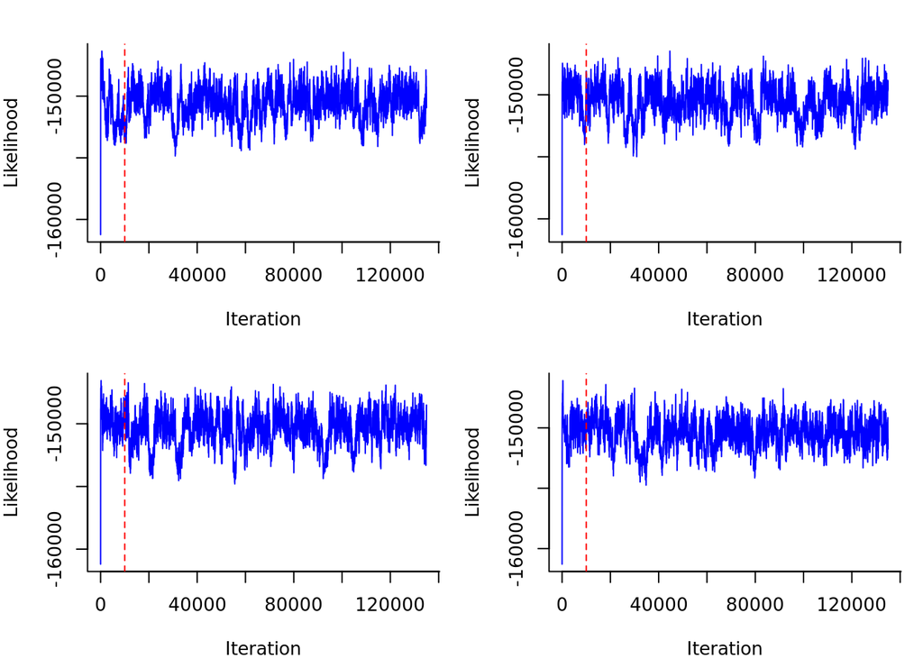

```r
    par(mfrow=c(2,2), mar=c(4, 4, 2, 1))
    p1 <- lapply(chains(hdpres2), plot_lik, bty="L")
```

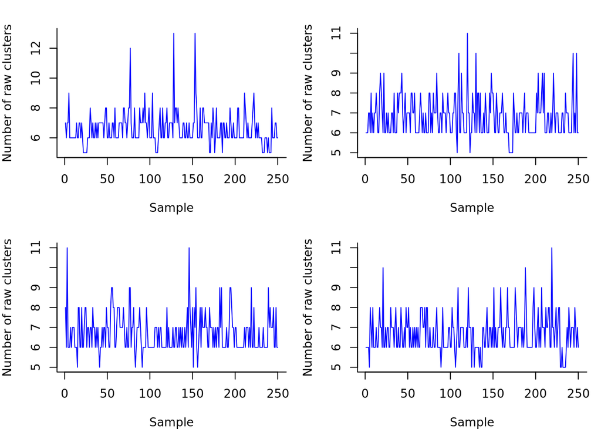

```r
    p2 <- lapply(chains(hdpres2), plot_numcluster, bty="L")
```

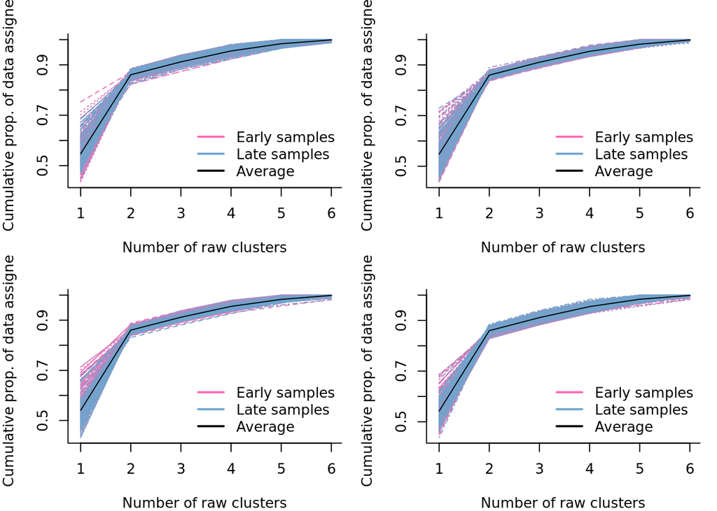

```r
    p3 <- lapply(chains(hdpres2), plot_data_assigned, bty="L")
```

### iv. Component count - n5

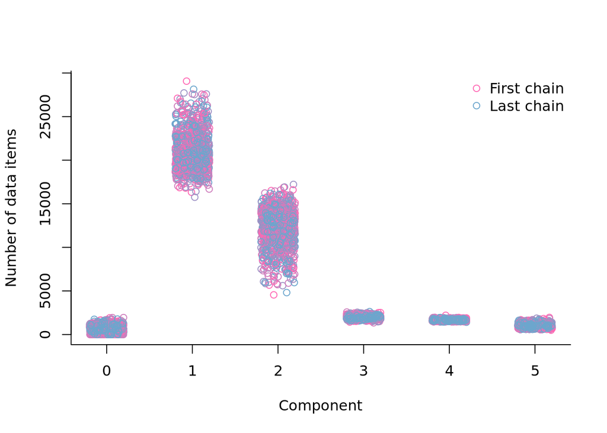

```r
plot_comp_size(hdpres2, bty="L", lab=c(3, 5, 7))
```

### v. Process HDP results and assign known signatures

Known signatures are assigned if cosine similarity is greater than 0.95

```r
 hdp2 <- extract_details_from_hdpres(
   res = hdpres2,
   priorsigs = pcawg,
   mutcount = mc2, threshold = 0.95
 )
```

## c. Check reconstruction error

Per Sample reconstruction error. Highlight samples with counts>200 that have reconstruction cosine similarity < 0.9:

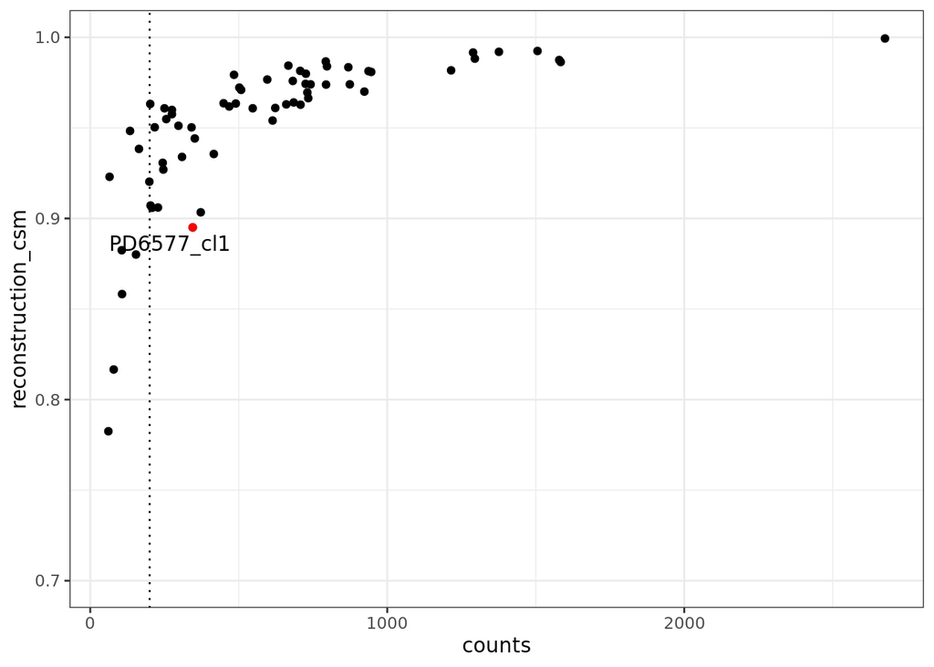

```r
df <- data.frame(counts = colSums(mc2), reconstruction_csm = hdp2$sample_csm, label = colnames(mc2))
ggplot(df, aes(x = counts, y = reconstruction_csm, label = label)) +
  geom_point() +
  geom_text_repel(data = df %>% filter(counts > 200 & reconstruction_csm < 0.9)) +
  geom_point(data = df %>% filter(counts > 200 & reconstruction_csm < 0.9), col = "red") +
  ylim(c(0.7, 1)) + geom_vline(xintercept = 200, lty = 3)
```

### i. PD6577_cl1 - No driver TN-ET

```r
clone_driver.key.n104 %>%  filter(cluster_name == "PD6577_cl1")
```

| Patient | category_label | cluster_no | In.vignette | Clone_abv | cluster_name |
| --- | --- | --- | --- | --- | --- |
| PD6577 | Stable | cl1 | TRUE | No driver | PD6577_cl1 |

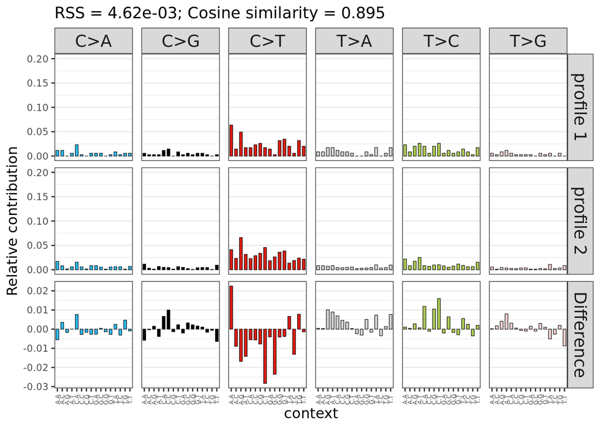

```r
plot_compare_profiles(profile1 = hdp2$mutcount[,"PD6577_cl1"], profile2 = hdp2$reconstruction["PD6577_cl1", ])
```

# 2. Results

## a. Extracted signatures

### i. Plot components

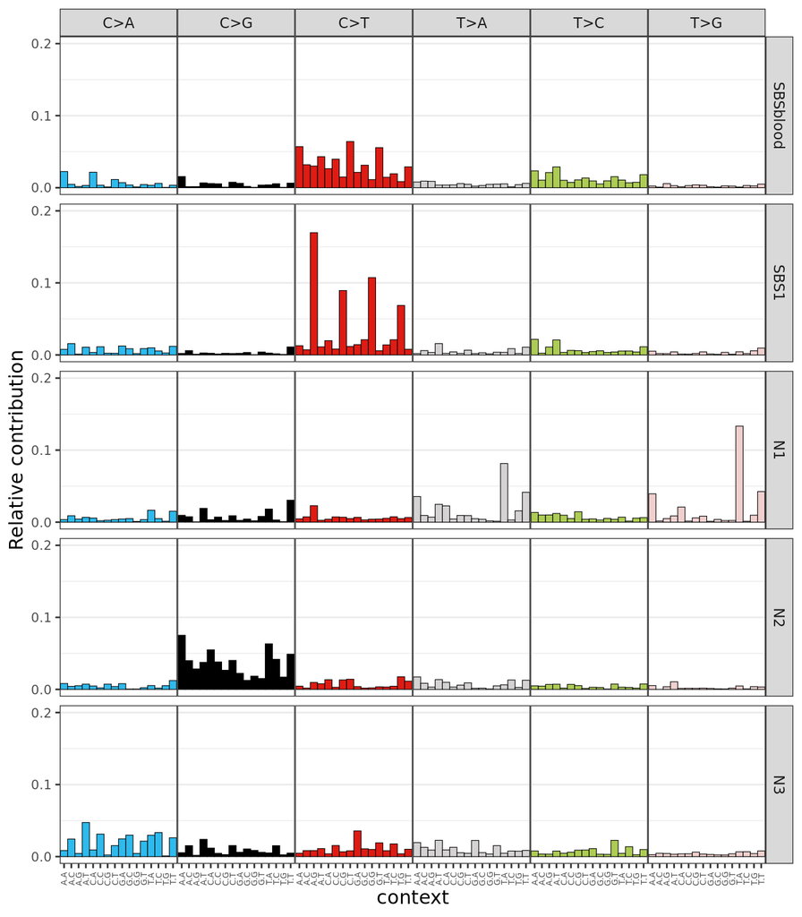

```r
plot_96_profile(hdp2$signatures, condensed = T)
```

### ii. Component similarity to COSMIC

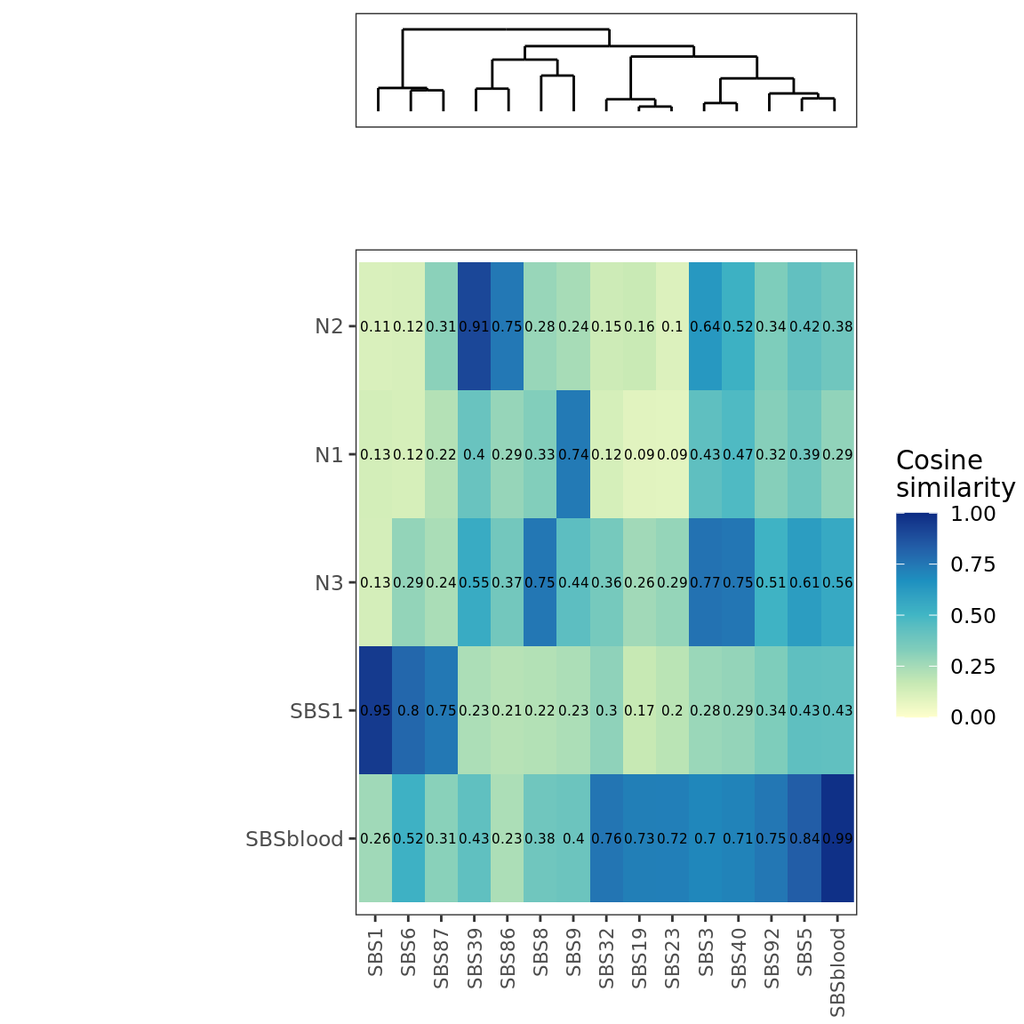

```r
csm <- cos_sim_matrix(hdp2$signature, pcawg)
csm2 <- csm[, apply(csm, 2, max) > 0.7]

plot_cosine_heatmap(csm2, cluster_rows = TRUE, cluster_cols = TRUE, plot_values = TRUE)
```

### iii. Rename Novel signatures

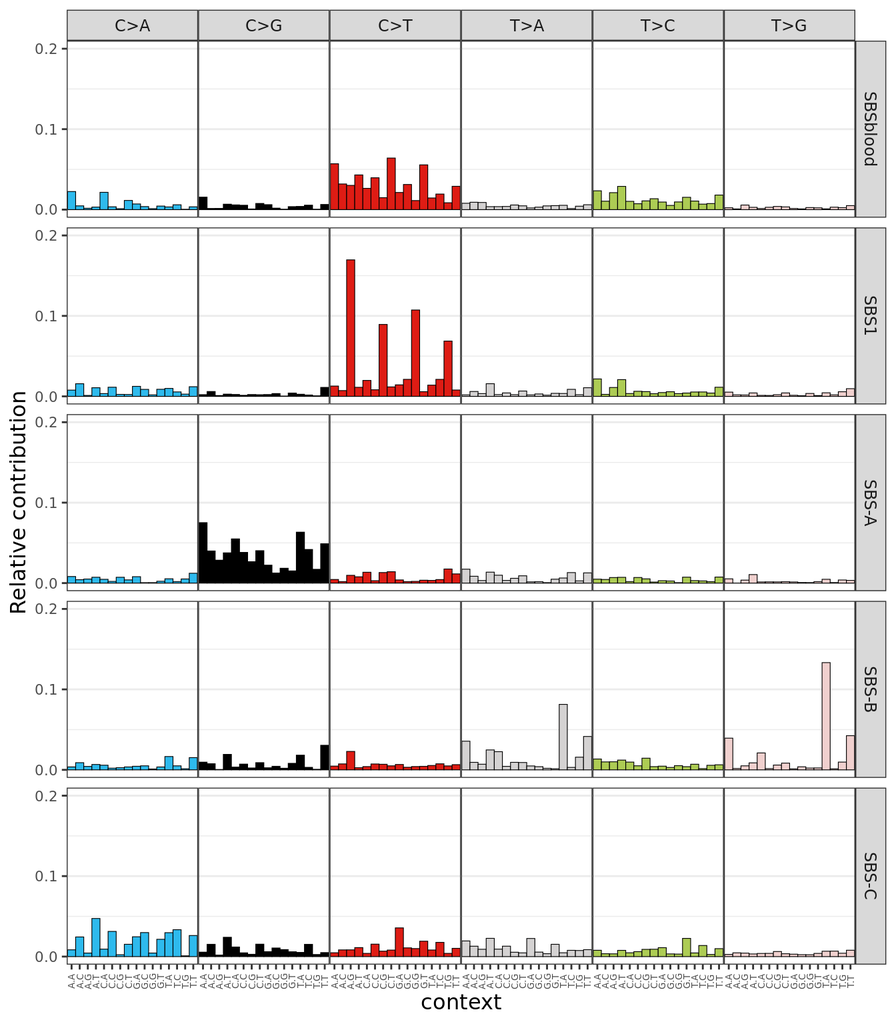

```r
signatures.mat <- hdp2$signatures

sig.rename.vec <- c("SBSblood" ="SBSblood", "SBS1" = "SBS1",  "N1" = "SBS-B", "N2" = "SBS-A", "N3" = "SBS-C")

colnames(signatures.mat) <- sig.rename.vec[colnames(signatures.mat) ]

plot_96_profile(signatures.mat[,c("SBSblood", "SBS1",  "SBS-A", "SBS-B", "SBS-C")], condensed = T)
```

```r
saveRDS(signatures.mat,"bulk_signatures.RDS")
```

## d. Signature contribution

### i. All clones n=64

```r
hdp2.tb <- contibutionPlot.data(hdp = hdp2, clone.key = clone_driver.key.n104)
## Joining with `by = join_by(Signature, Sample)`
## Joining with `by = join_by(Signature, Sample)`
## Joining with `by = join_by(Patient, cluster_no)`
## Joining with `by = join_by(Sample)`
## Joining with `by = join_by(Sample)`
```

```r
dim(hdp2.tb)
```

```
## [1] 320  13
```

#### 1) Rename and group sigs

Signature attributions where the lower bound = 0 are categorised as unassigned

```r
sig.col.vec <- rev(c(unassigned = "black", `SBS-C` = "#5A96BF",  `SBS-B` ="#995763", `SBS-A` ="#50A382", SBS1 = "#99968C",  SBSblood = "#D3927C"))

hdp2.tb.anno.df <-
  hdp2.tb %>%
  mutate(Signature.orig = Signature) %>%
  mutate(Signature = factor(case_when(
    Signature.orig == "N1" & Contribution_lb95 > 0 ~ "SBS-B",
    Signature.orig == "N2" & Contribution_lb95 > 0 ~ "SBS-A",
    Signature.orig == "N3" & Contribution_lb95 > 0 ~ "SBS-C",
    Contribution_lb95 == 0 ~ "unassigned", TRUE ~ Signature.orig
  ), levels = names(sig.col.vec))) %>%
  mutate(Sig_type = case_when(Signature  %in%  c("SBS1", "SBSblood") ~ "Endogenous", TRUE ~ "Novel"))
```

#### 2) Relative and absolute Barplot

```r
n64.con_barplot <-
  contibutionPlot.con_plot(tb = hdp2.tb.anno.df, facet = "category_label") + scale_fill_manual(values = sig.col.vec) + scale_colour_manual(values = sig.col.vec)
## Scale for fill is already present.
## Adding another scale for fill, which will replace the existing scale.
```

```r
n64.abs_barplot <-
  contibutionPlot.abs_plot(tb = hdp2.tb.anno.df, facet = "category_label") + scale_fill_manual(values = sig.col.vec) + scale_colour_manual(values = sig.col.vec)
## Scale for fill is already present.
## Adding another scale for fill, which will replace the existing scale.
```

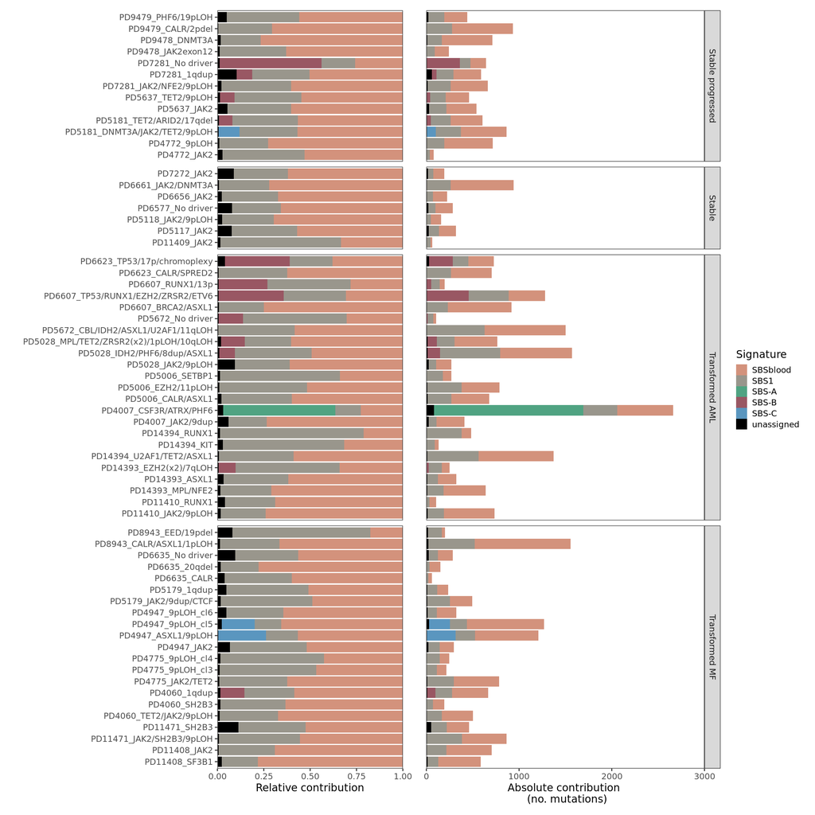

```r
n64.con_barplot +
  plot_spacer() +
  n64.abs_barplot +
  plot_layout(widths = c(0.4, 0.0005, 0.6), guides = "collect")
```

#### 3) Clone level signature relative contributions

Signature attributions where the lower bound = 0 are not plotted

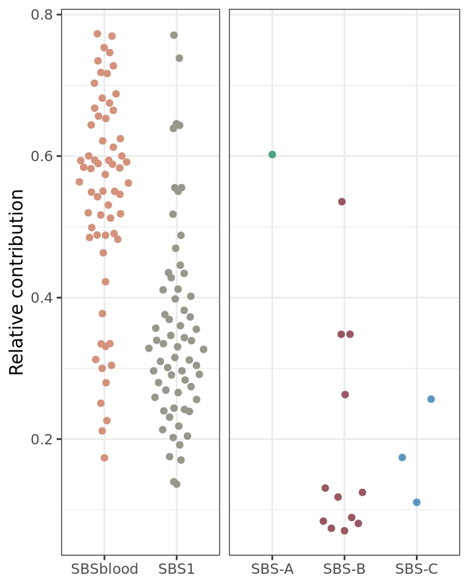

```r
  hdp2.tb.anno.df %>%
  filter(Contribution_lb95 > 0) %>%
  ggplot(aes(x = Signature, y = Contribution, color = Signature)) +
  ggbeeswarm::geom_quasirandom(size = 1.5) +
  facet_grid(. ~ Sig_type, scales = "free_x", space = "free_x") +
  scale_colour_manual(values = sig.col.vec) +
  theme_bw() +
  labs(y = "Relative contribution", x = NULL) +
  theme(
    legend.position = "none",
    strip.background = element_blank(),
    strip.text = element_blank()
  )
```

### ii. Novel signature high burden clones n=6

#### 1) Select high exposure samples (> 0.20) and untreated patient clones (PD9478) n8

```r
outlier.exposure.list <-
  list(
    "Aza" = rownames(hdp2$contr)[hdp2$contr[, "N2"] > 0.2],
    "Hydroxycarbamide" = rownames(hdp2$contr)[hdp2$contr[, "N1"] > 0.2],
    "SBS-C" = rownames(hdp2$contr)[hdp2$contr[, "N3"] > 0.2],
    "Untreated" = grep("PD9478", colnames(mc2), value = T)
  )

outlier.exposure.list
```

```
## $Aza
## [1] "PD4007_cl3"
##
## $Hydroxycarbamide
## [1] "PD6607_cl3" "PD6607_cl6" "PD6623_cl4" "PD7281_cl5"
##
## $`SBS-C`
## [1] "PD4947_cl3"
##
## $Untreated
## [1] "PD9478_cl1" "PD9478_cl3"
```

##### a) Plot spectra

Plot clone level spectra of outlier and untreated n8

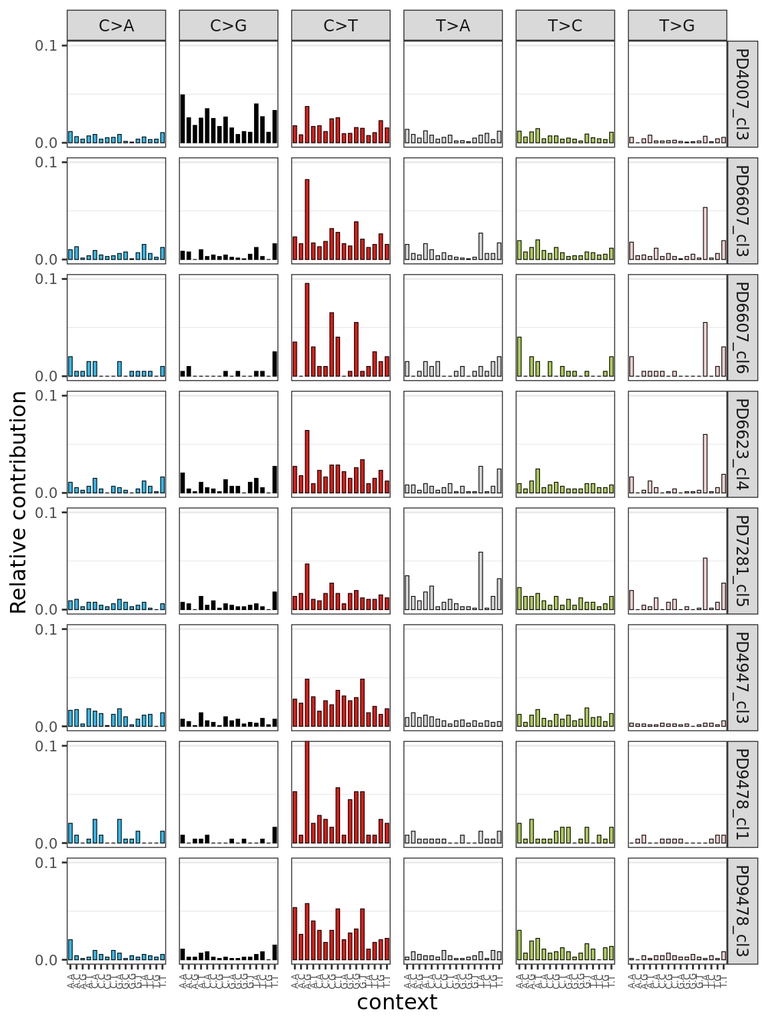

```r
plot_96_profile(mc2[,unlist(outlier.exposure.list)], ymax = 0.1)
```

##### b) Subset outlier/untreated clones

```r
outlier.tb <-
  right_join(
    hdp2.tb.anno.df,
    unlist(lapply(names(outlier.exposure.list), function(x) {
      d <-
        outlier.exposure.list[[x]]
      names(d) <-
        rep(x, length(d))
      d
    })) %>% enframe(name = "Group", value = "Sample")
  )
## Joining with `by = join_by(Sample)`
```

```r
outlier.tb %<>% mutate(Group = factor(as.character(Group),
  levels = names(outlier.exposure.list)
))

outlier.tb %<>% mutate(Clone_abv = factor(as.character(Clone_abv),
  levels = rev(c(
    "PD4007_CSF3R/ATRX/PHF6",
    "PD7281_No driver",
    "PD6607_TP53/RUNX1/EZH2/ZRSR2/ETV6",
    "PD6623_TP53/17p/chromoplexy",
    "PD6607_RUNX1/13p",
    "PD4947_ASXL1/9pLOH",
    "PD9478_DNMT3A",
    "PD9478_JAK2exon12"
  ))
))

outlier.tb %>%  select(Patient, category_label, Clone_abv) %>% distinct()
```

| Patient | category_label | Clone_abv |
| --- | --- | --- |
| PD4007 | Transformed AML | PD4007_CSF3R/ATRX/PHF6 |
| PD4947 | Transformed MF | PD4947_ASXL1/9pLOH |
| PD6607 | Transformed AML | PD6607_TP53/RUNX1/EZH2/ZRSR2/ETV6 |
| PD6607 | Transformed AML | PD6607_RUNX1/13p |
| PD6623 | Transformed AML | PD6623_TP53/17p/chromoplexy |
| PD7281 | Stable progressed | PD7281_No driver |
| PD9478 | Stable progressed | PD9478_JAK2exon12 |
| PD9478 | Stable progressed | PD9478_DNMT3A |

#### 2) Relative and absolute Barplot

```r
outlier.con_barplot <-
  contibutionPlot.con_plot(tb = outlier.tb, facet = "Group") + scale_fill_manual(values = sig.col.vec) + scale_colour_manual(values = sig.col.vec)
## Scale for fill is already present.
## Adding another scale for fill, which will replace the existing scale.
```

```r
outlier.abs_barplot <-
  contibutionPlot.abs_plot(tb = outlier.tb, facet = "Group") + scale_fill_manual(values = sig.col.vec) + scale_colour_manual(values = sig.col.vec)
## Scale for fill is already present.
## Adding another scale for fill, which will replace the existing scale.
```

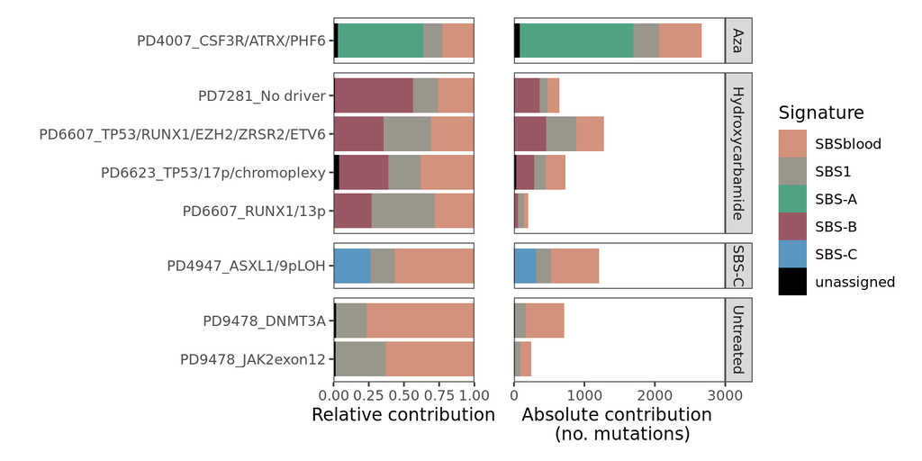

```r
outlier.con_barplot +
  plot_spacer() +
  outlier.abs_barplot +
  plot_layout(widths = c(0.4, 0.0005, 0.6), guides = "collect")
```